# Generalized Linear Models

Alejandro Vaca Serrano

13 de febrero de 2019

Primero leemos los datos y pasamos todas las variables categóricas a factor, ya sean ordenados o no (dependiendo de la variable):

## Primera Parte: variable nbaffairs

Hacemos primero la partición de la muestra; nos quedamos con un 85% de las observaciones para entrenar y nos olvidamos del 15% restante hasta la última fase, la de predecir.

```r
set.seed(100)
index <- sample(nrow(fair), size = nrow(fair)*0.85)


train <- fair[index, ]

test <- fair[-index, ]
```

Vamos a ver de qué tipo es la variable nbaffairs.

```r
summary(fair$nbaffairs)
```

```
##    Min. 1st Qu.  Median    Mean 3rd Qu.    Max.
##   0.000   0.000   0.000   1.456   0.000  12.000
```

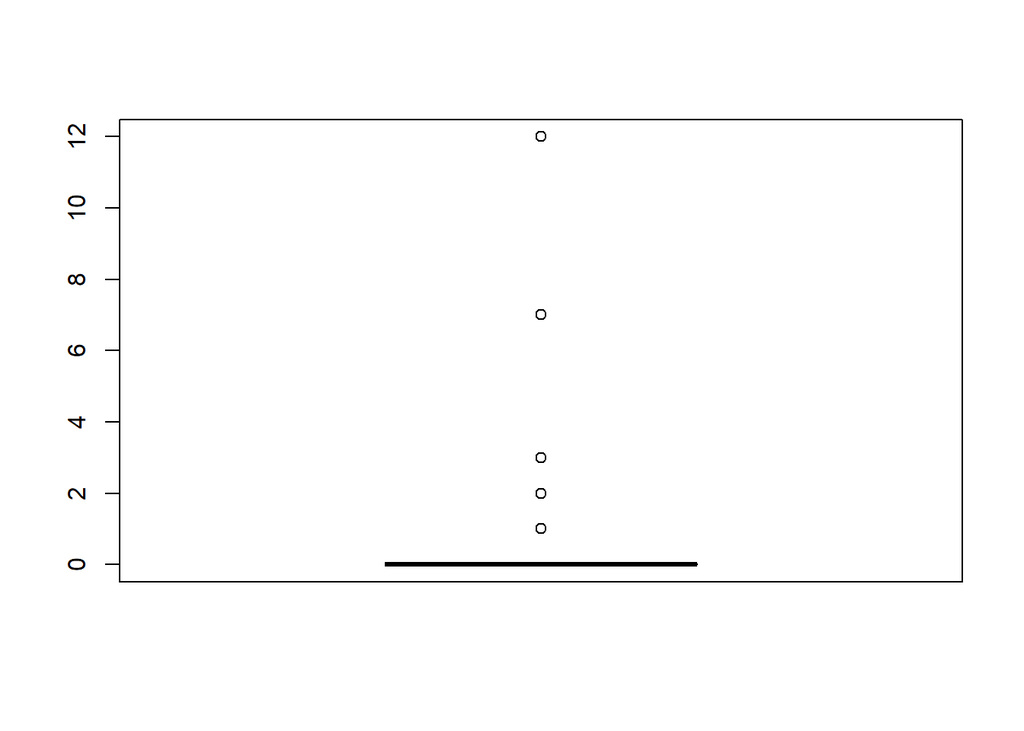

```r
boxplot(fair$nbaffairs)
```

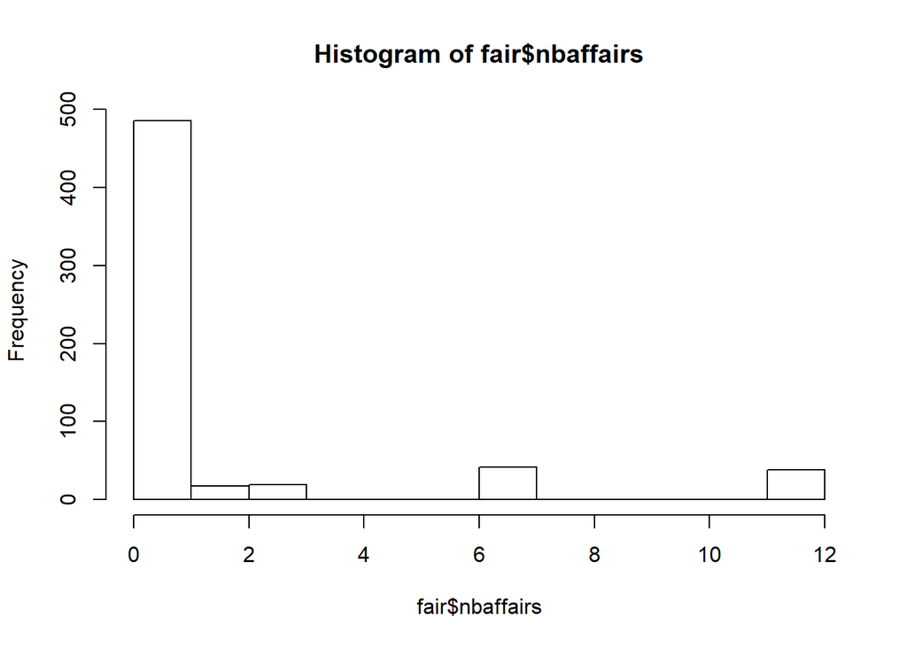

```r
hist(fair$nbaffairs)
```

Parece claro que es una variable de conteo, ya que cuenta el número de veces en un año que los distintos individuos de la muestra han tenido relaciones extramatrimoniales.

Vamos a realizar ahora un scatterplot sobre cada una de las otras variables con respecto a nbaffairs:

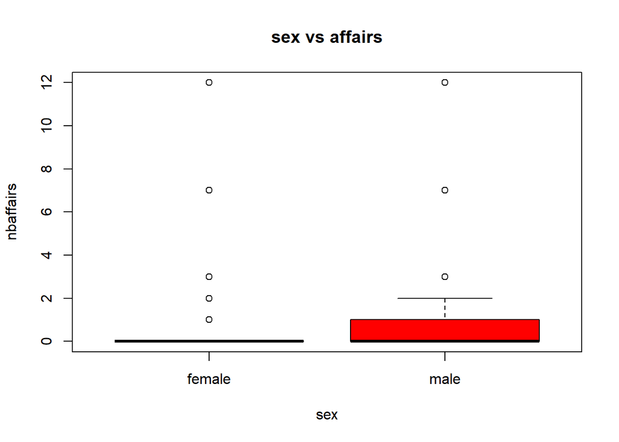

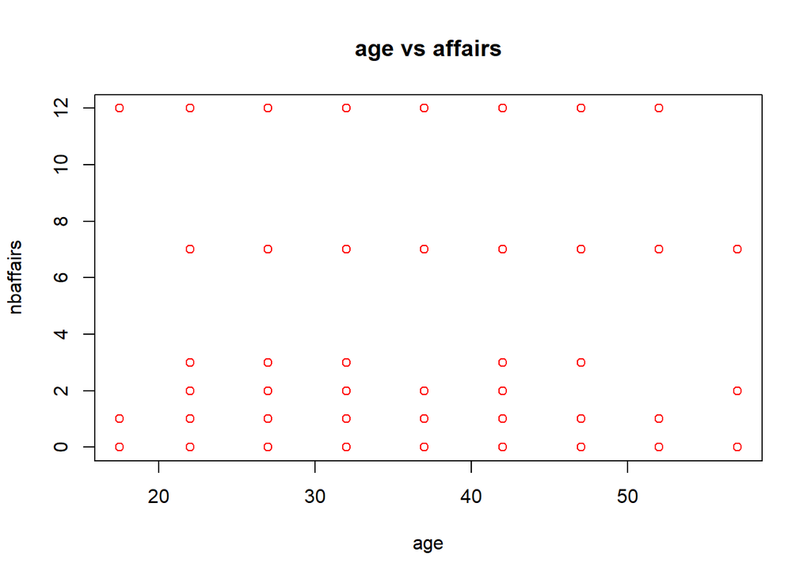

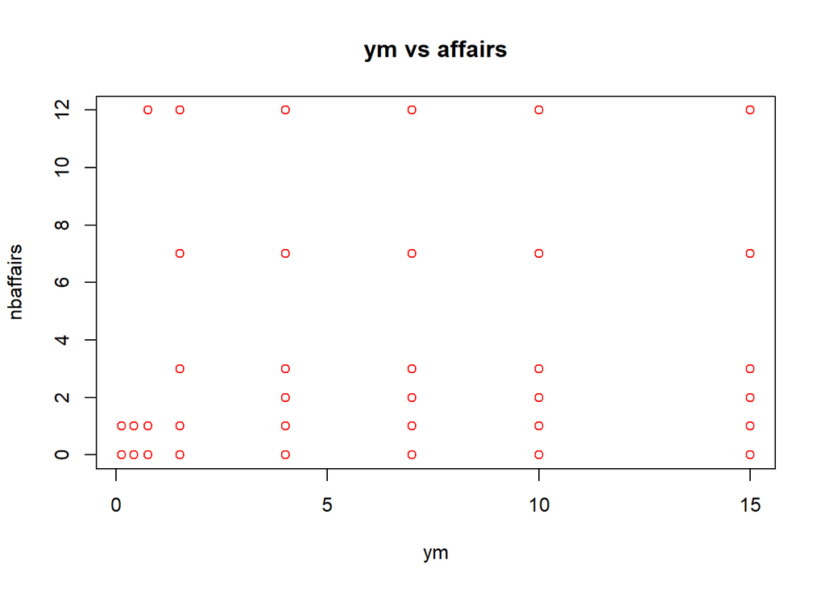

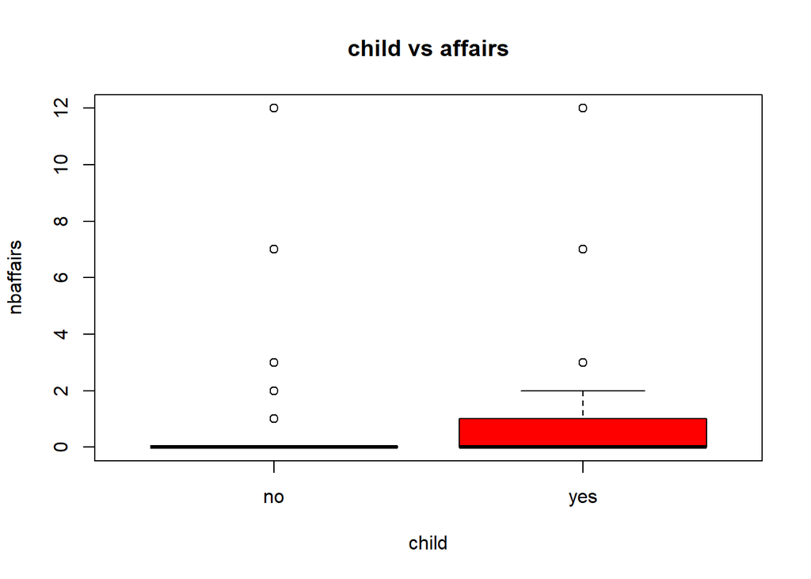

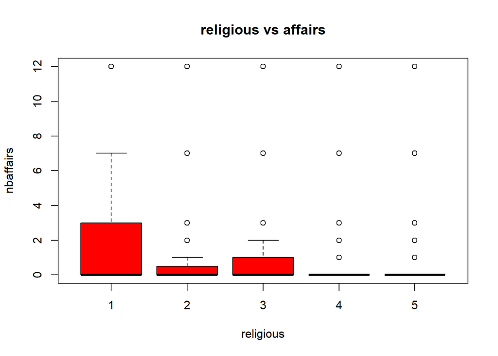

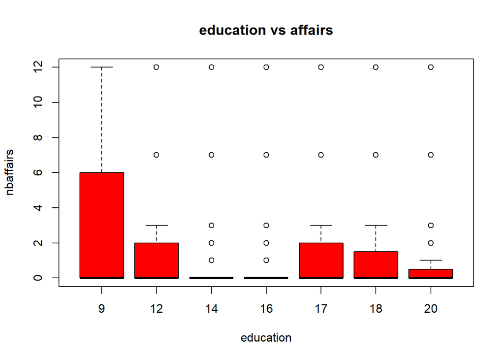

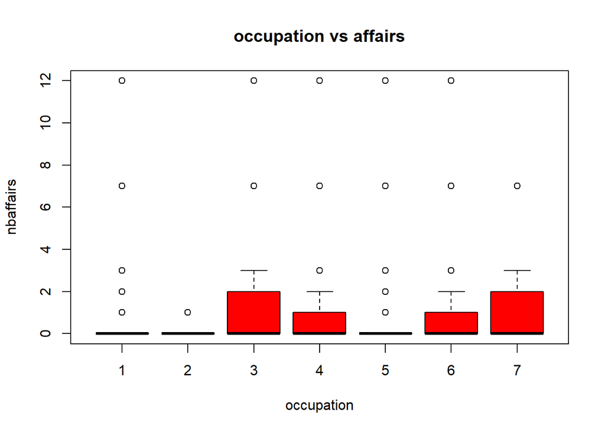

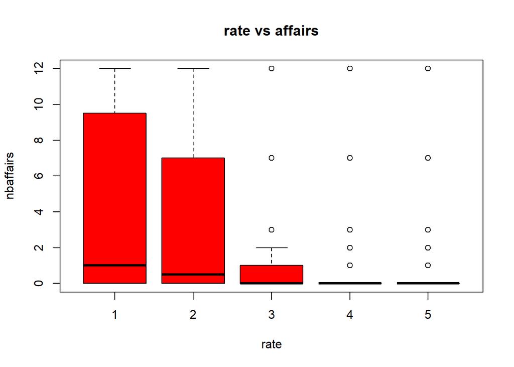

```r
for(i in 1:(ncol(fair) - 1)) {

  plot(x = fair[ ,i], y = fair[, 'nbaffairs'], main = paste0(names(fair)[i], ' vs affairs'), col = 'red', xlab = names(fair)[i],
       ylab = "nbaffairs")

}
```

Vemos que los hombres cometen algunas infidelidades más que las mujeres, al menos visualmente es lo que parece indicarse; no se observa una relación clara entre la edad y el número de infidelidades en el último año. Las parejas que tienen niños parecen tener algunos affairs más, en media, que las personas sin hijos. Además, parece haber una relación inversa entre el nivel de religiosidad de las personas y sus infidelidades en el último año, pues como vemos en el gráfico, la parte central del boxplot se va aplastando y tendiendo al 0 según el nivel de religiosidad sube. Un suceso más o menos parecido nos encontramos en el caso de la educación, en el que vemos además que hay muchos outliers; esto es algo que vemos en otros gráficos, y que indica que aunque en media si existe una relación entre la variable (en este caso, education) y nbaffairs, hay casos de mucha infidelidad para personas de educación alta también; esto viene a decir que hay muchos casos en los que un número grande de infidelidades no se puede explicar por nuestras variables explicativas. Al haber tantas variables ausentes en el modelo relativas a la psicología propia de la persona, nos van a faltar muchos datos para poder explicar bien los motivos de la infidelidad de cada individuo. Parece ser que cuando la ocupación de la persona es más alta (mayor nivel), las infidelidades suben un poco en media, aunque este efecto no está del todo claro. Por ejemplo, parece que los individuos con ocupación 3 y los individuos con ocupación 7 tienen un diagrama de cajas muy parecido para el número de infidelidades cometidas en el último año. Por lo tanto, seguramente esta variable salga no significativa. Sí vemos una relación clara entre el rate que le da cada individuo a la satisfacción matrimonial y el número de infidelidades del último año, pues como vemos los boxplots son descendentes, es decir en general cometen más infidelidades las personas que tienen un nivel de satisfacción con el matrimonio menor.

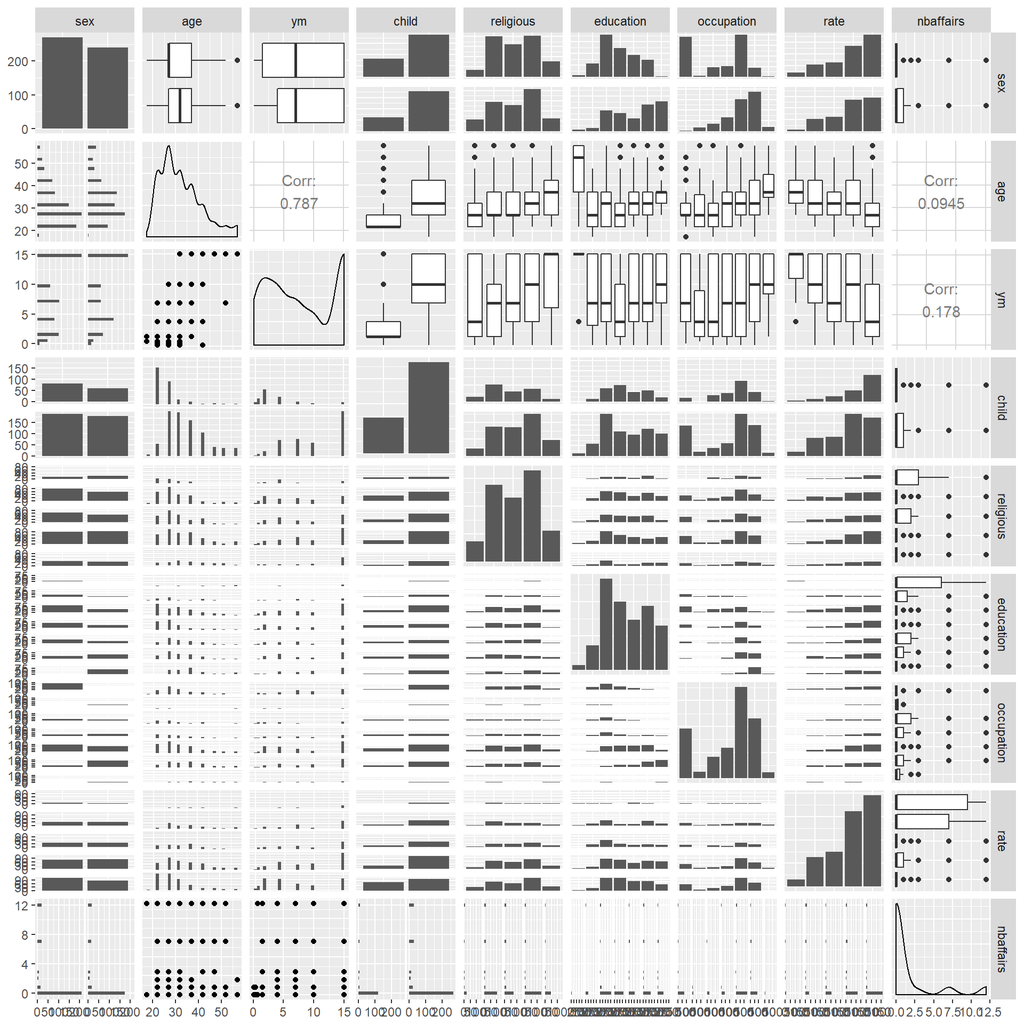

```r
library(GGally)

ggpairs(train, color = "blue")
```

En el gráfico de arriba podemos ver más o menos lo mismo que vimos en los gráficos anteriores con respecto a las relaciones entre las variables.

Vamos a hacer algunos gráficos más, solo para las variables más significativas, para visualizar un poco más los datos antes de comenzar a modelizar. En este apartado también trataremos de ver las relaciones de las variables con rate, pues la segunda parte del trabajo irá dirigido a modelizar esta otra variable.

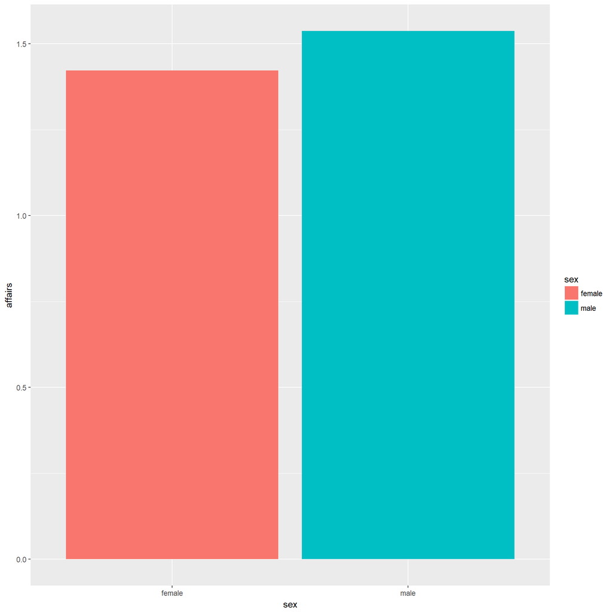

```r
train %>%
  group_by(sex) %>%
  summarise(affairs = mean(nbaffairs)) %>%
  ggplot(aes(x = sex,
             y=affairs,
             fill=sex)) +
  geom_histogram(stat='identity')
```

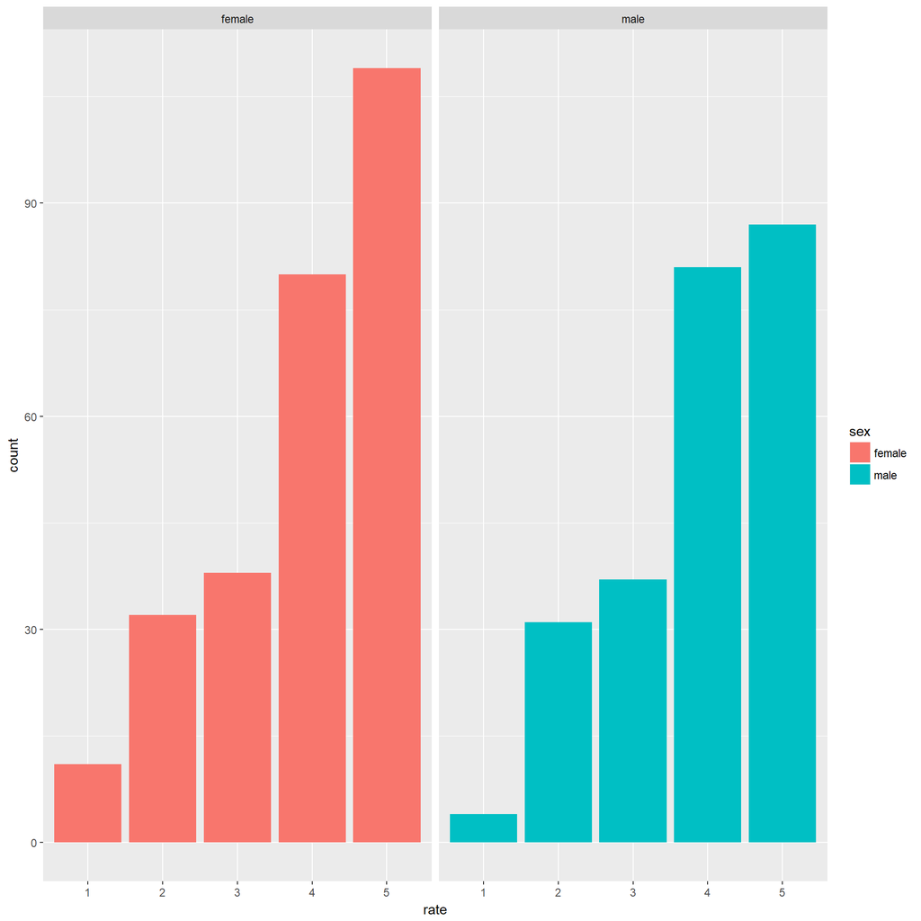

```r
train %>%
  ggplot(aes(x = rate,fill=sex))+
  geom_bar(position = "dodge")+
  facet_grid(~sex)
```

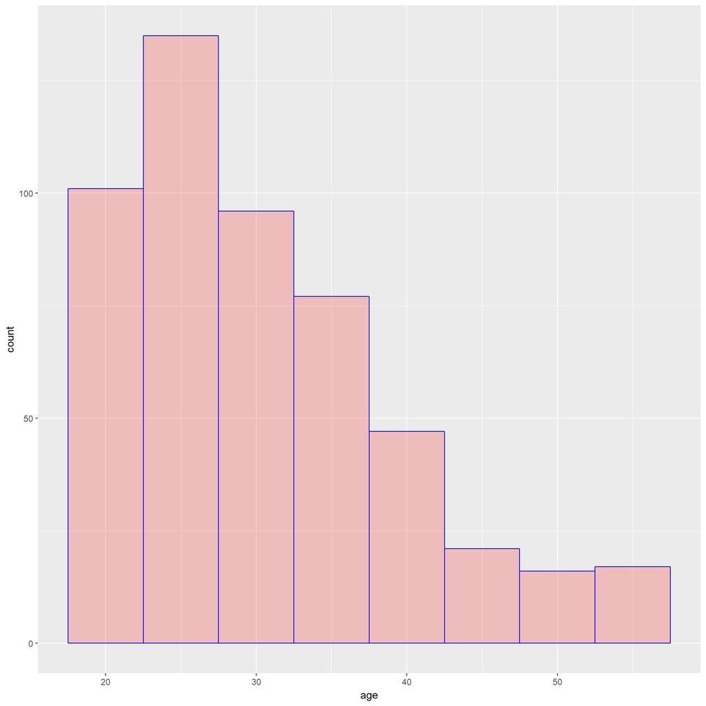

```r
train %>%
  ggplot(aes(age))+
  geom_histogram(binwidth = 5, col='blue',fill='red',alpha=.2)
```

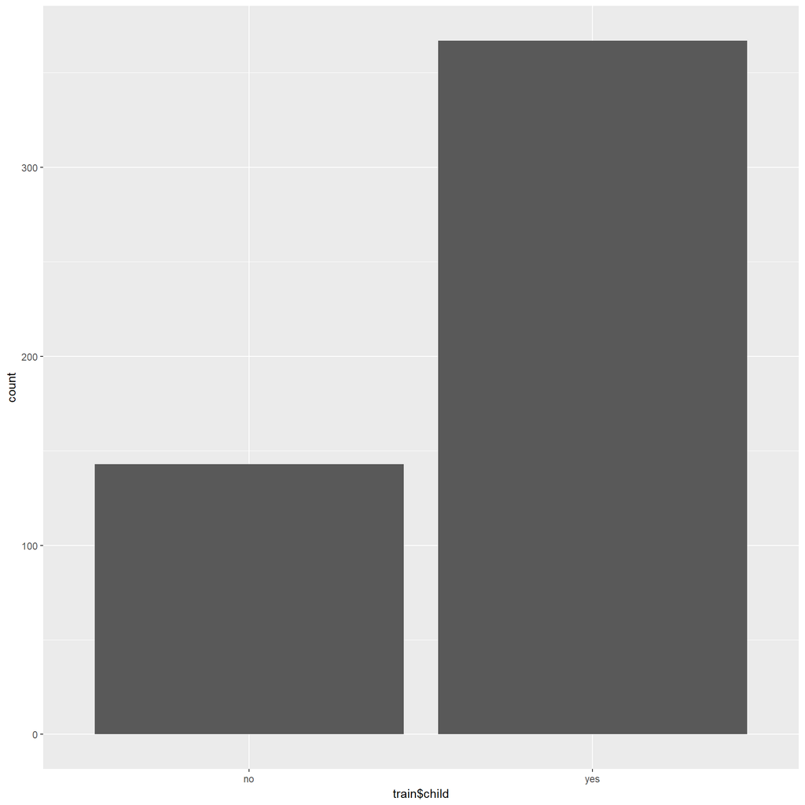

```r
qplot(train$child)
```

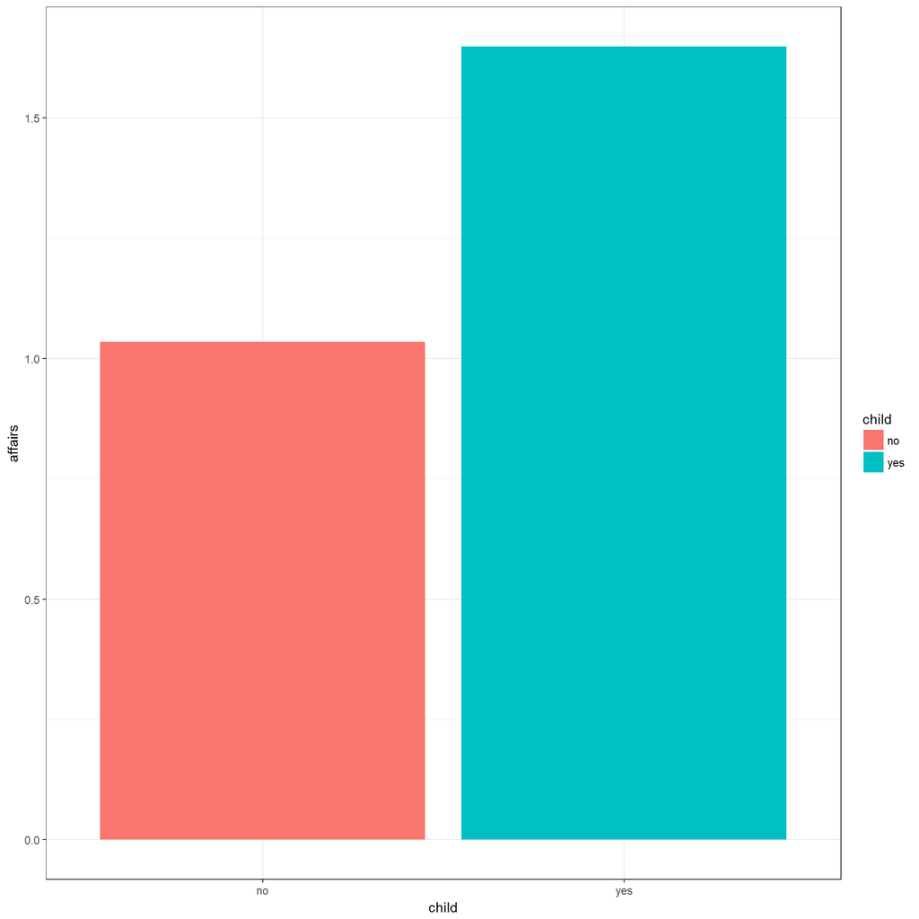

```r
# Hay poco menos de hombres, pero bien balanceado

# La gente con hijos, de media, es más infiel
train %>%
  group_by(child) %>%
  summarise(affairs = mean(nbaffairs)) %>%
  ggplot(aes(x = child,
             y=affairs,
             fill=child)) +
  geom_histogram(stat='identity') +
  theme_bw()
```

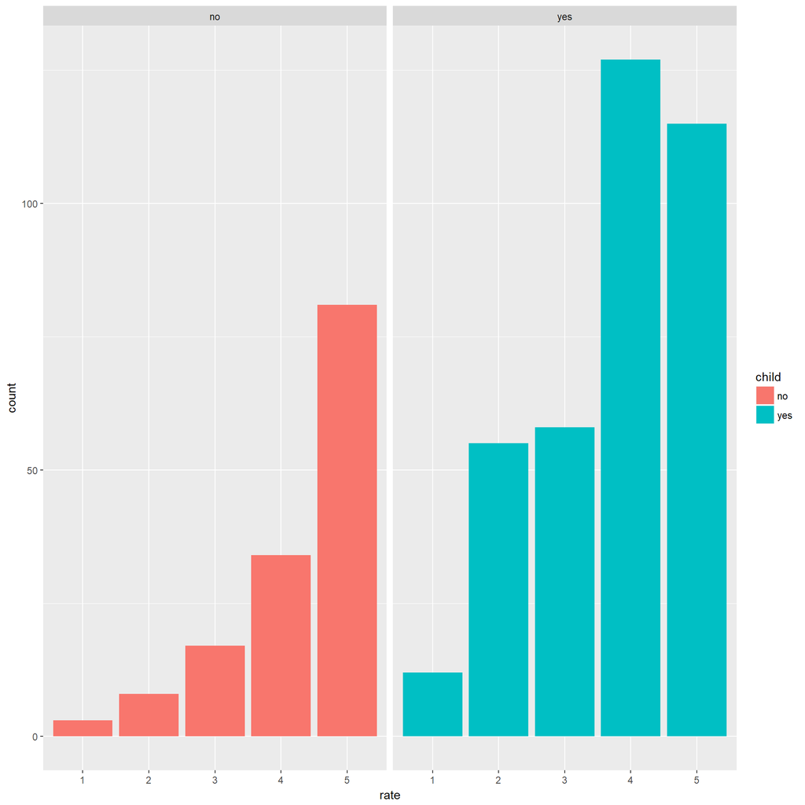

```r
train %>%
  ggplot(aes(x = rate,fill=child))+
  geom_bar(position = "dodge")+
  facet_grid(~child)
```

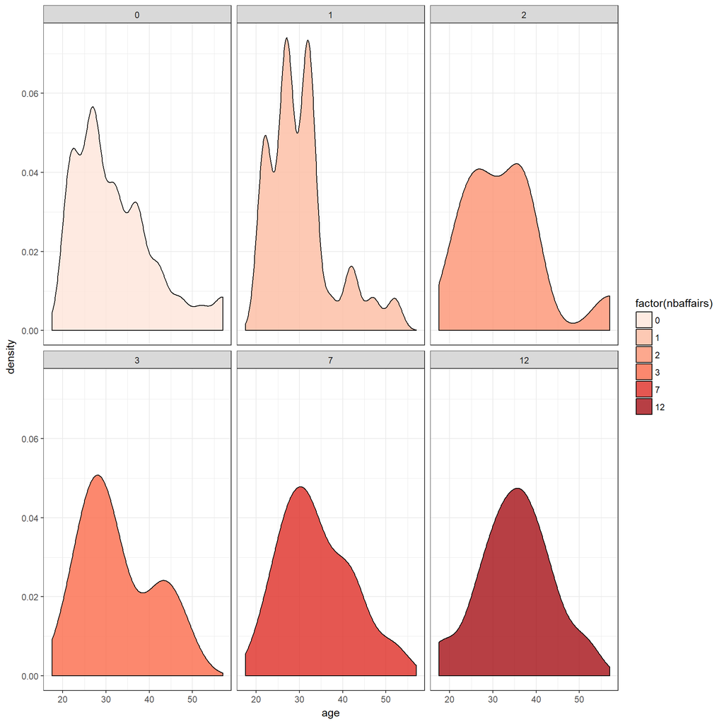

```r
train %>%
 group_by(factor(nbaffairs)) %>%
 ggplot(aes(x = age, fill=factor(nbaffairs))) +
 geom_density(alpha=0.8)+
 facet_wrap(~ factor(nbaffairs))+
 scale_fill_brewer(palette = 'Reds') +
 theme_bw()
```

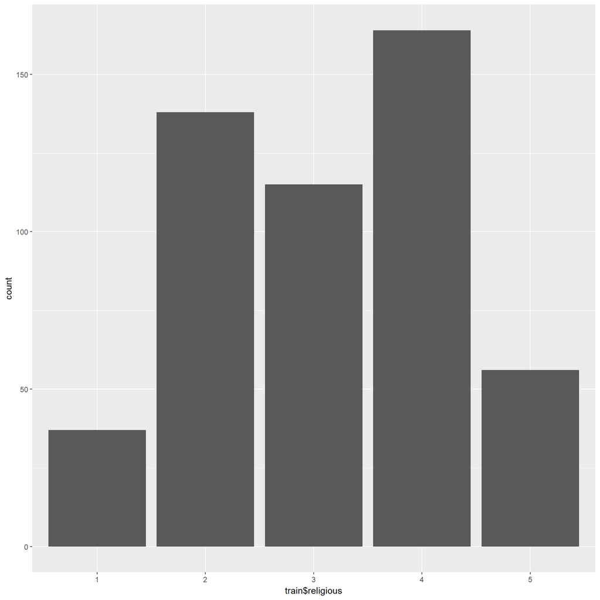

```r
qplot(train$religious)
```

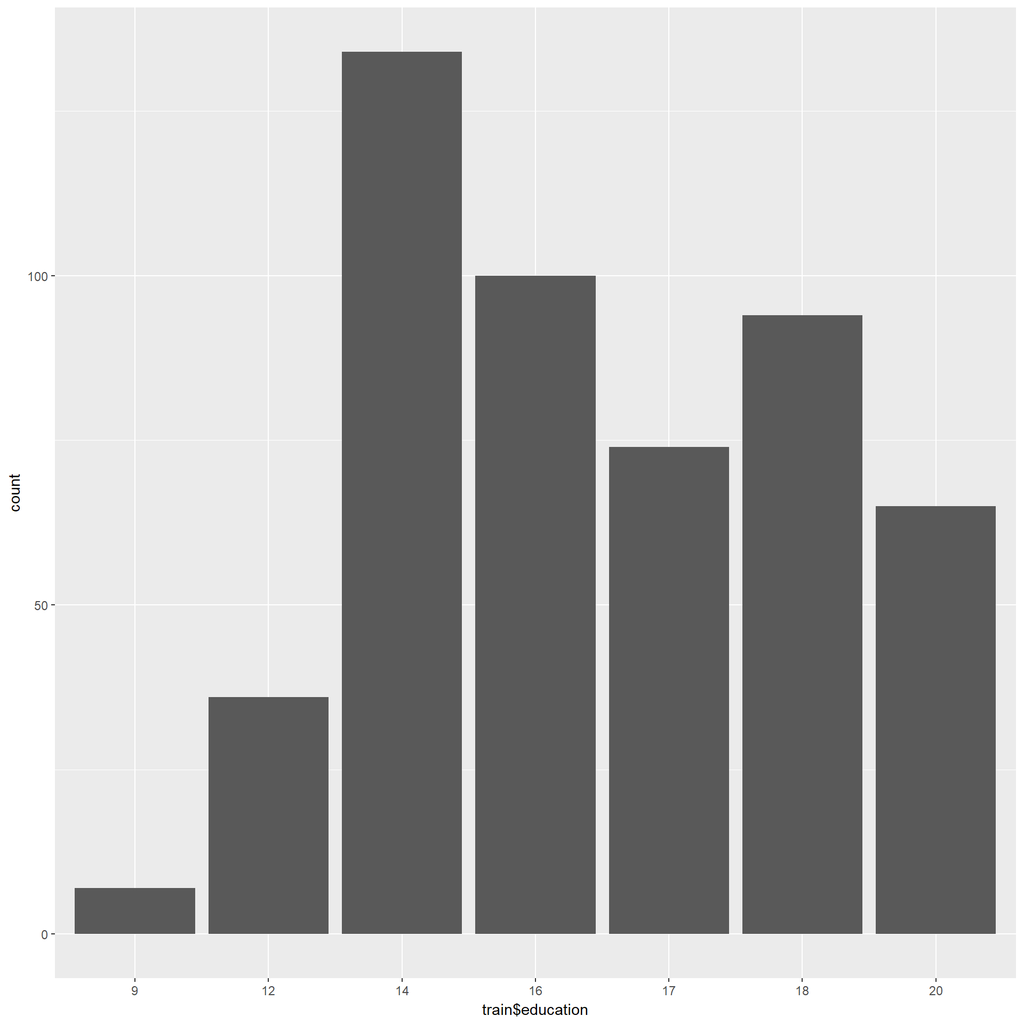

```r
qplot(train$education)
```

```r
table(train$education)
```

```
##
##   9  12  14  16  17  18  20
##   7  36 134 100  74  94  65
```

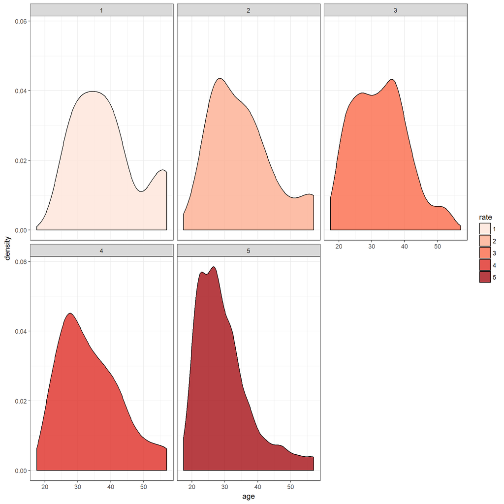

```r
train %>%
 group_by(rate) %>%
 ggplot(aes(x = age, fill=rate)) +
 geom_density(alpha=0.8)+
 facet_wrap(~ rate)+
 scale_fill_brewer(palette = 'Reds') +
 theme_bw()
```

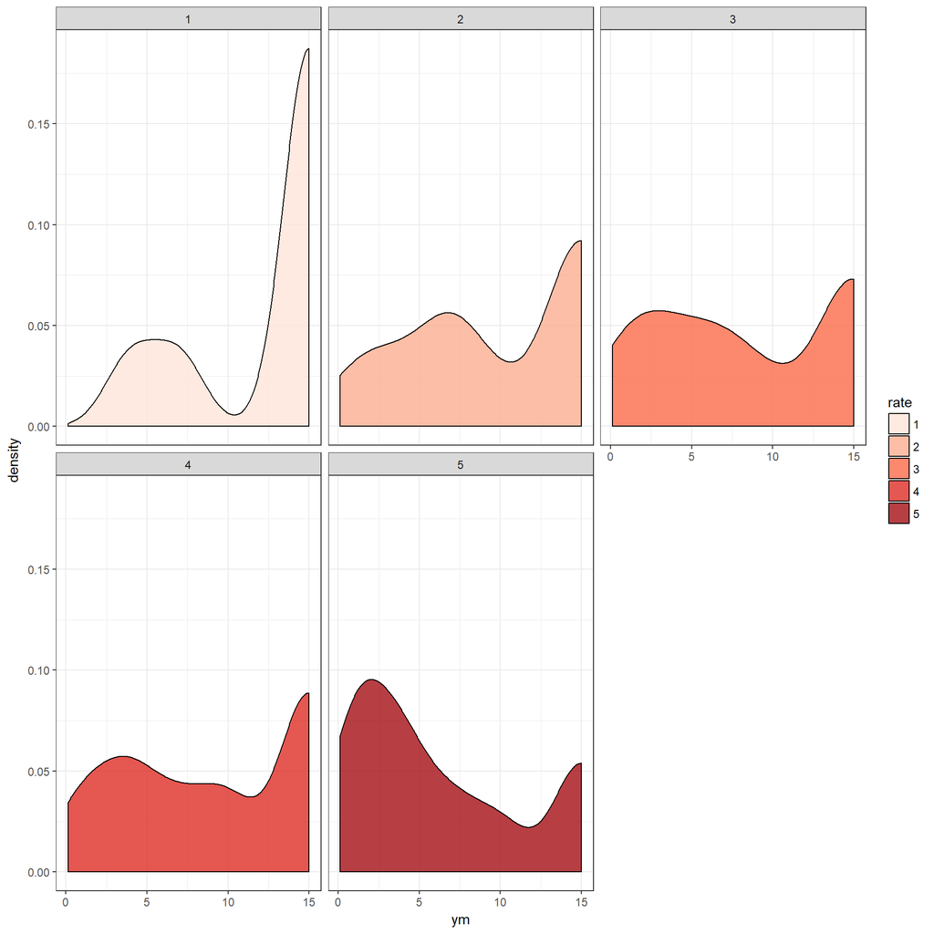

```r
train %>%
 group_by(rate) %>%
 ggplot(aes(x = ym, fill=rate)) +
 geom_density(alpha=0.8)+
 facet_wrap(~ rate)+
 scale_fill_brewer(palette = 'Reds') +
 theme_bw()
```

Vemos que la variable religious se distribuye casi como una normal, siendo la mayoría de personas medianamente religiosas, con pocas observaciones en el nivel 1 o en el 5. Vemos que la mayoría de la gente tiene niveles de educación elevados, por encima de 14. Es algo asimétrica la distribución, sin demasiadas apreciaciones exageradas.

Curiosamente la gente es más feliz en pareja cuando es más joven. Esto encaja con la idea previa que tenemos, y es que deprimentemente, todo con el tiempo se marchita, también el amor. La gente es bastante más feliz en pareja al rededor de los 20 o 30 años.

Estos mismos resultados se ven reflejados cuando tratamos de ver la relación entre la variable years married y la variable rate; como vemos en el último gráfico, la gente que tiene un rate más bajo lleva más años casada en general.

En primer lugar, vamos a realizar un modelo muy sencillo, con todas las variables, que únicamente nos distinga si la variable es 0 o no. Como vimos en el anterior histograma y en el boxplot de la variable nbaffairs, hay muchas observaciones con 0 (o los americanos son muy fieles, o muy mentirosos; al menos en el 70-71, cuando se hizo la encuesta).

```r
train2 <- train

train2$nbaffairs <- ifelse(train2$nbaffairs > 0, 1, 0)

fit <- glm(nbaffairs ~., family = binomial(link = "logit"), data = train2)

summary(fit)
```

```
##
## Call:
## glm(formula = nbaffairs ~ ., family = binomial(link = "logit"),
##     data = train2)
##
## Deviance Residuals:
##     Min       1Q   Median       3Q      Max
## -1.5462  -0.7521  -0.5210  -0.2581   2.7939
##
## Coefficients:
##             Estimate Std. Error z value Pr(>|z|)
## (Intercept) -0.60204    0.61973  -0.971 0.331327
## sexmale      0.31148    0.28329   1.100 0.271535
## age         -0.04703    0.02148  -2.190 0.028537 *
## ym           0.10196    0.03679   2.771 0.005585 **
## childyes     0.24247    0.33172   0.731 0.464818
## religious.L -1.19847    0.35338  -3.391 0.000695 ***
## religious.Q  0.24406    0.31154   0.783 0.433395
## religious.C -0.11284    0.26017  -0.434 0.664505
## religious^4  0.72288    0.22389   3.229 0.001244 **
## education.L  0.27453    0.68951   0.398 0.690516
## education.Q -0.08819    0.59488  -0.148 0.882148
## education.C -0.15261    0.49035  -0.311 0.755627
## education^4 -0.25591    0.38526  -0.664 0.506533
## education^5  0.36857    0.30290   1.217 0.223676
## education^6  0.20146    0.27715   0.727 0.467289
## occupation2  0.59777    0.79298   0.754 0.450956
## occupation3  0.58135    0.48323   1.203 0.228956
## occupation4  0.59331    0.45474   1.305 0.191987
## occupation5 -0.02167    0.38719  -0.056 0.955373
## occupation6  0.05060    0.46883   0.108 0.914061
## occupation7 -0.09164    0.83156  -0.110 0.912250
## rate.L      -1.23415    0.42132  -2.929 0.003398 **
## rate.Q      -0.17564    0.37786  -0.465 0.642064
## rate.C       0.12234    0.28525   0.429 0.668012
## rate^4      -0.55647    0.27157  -2.049 0.040454 *
## ---
## Signif. codes:  0 '***' 0.001 '**' 0.01 '*' 0.05 '.' 0.1 ' ' 1
##
## (Dispersion parameter for binomial family taken to be 1)
##
##     Null deviance: 568.02  on 509  degrees of freedom
## Residual deviance: 495.29  on 485  degrees of freedom
## AIC: 545.29
##
## Number of Fisher Scoring iterations: 4
```

```r
1- (495.29/568.02)
```

```
## [1] 0.1280413
```

Como vemos el modelo es bastante pobre, y es que explica al rededor del 12-13% de la variable “ha engañado en el último año”.

Ahora, al ser una variable de conteo, vamos a probar a modelizarlo como una Poisson.

```r
fit <- glm(nbaffairs ~., family = poisson(link = "log"), data = train)

summary(fit)
```

```
##
## Call:
## glm(formula = nbaffairs ~ ., family = poisson(link = "log"),
##     data = train)
##
## Deviance Residuals:
##     Min       1Q   Median       3Q      Max
## -3.7475  -1.5010  -1.0713  -0.6031   9.1482
##
## Coefficients:
##              Estimate Std. Error z value Pr(>|z|)
## (Intercept)  0.487938   0.197692   2.468  0.01358 *
## sexmale      0.155300   0.094276   1.647  0.09950 .
## age         -0.035249   0.006769  -5.207 1.91e-07 ***
## ym           0.122850   0.012098  10.155  < 2e-16 ***
## childyes    -0.101796   0.112107  -0.908  0.36387
## religious.L -1.261424   0.117580 -10.728  < 2e-16 ***
## religious.Q  0.147755   0.103211   1.432  0.15227
## religious.C  0.068452   0.091173   0.751  0.45278
## religious^4  0.448094   0.076909   5.826 5.67e-09 ***
## education.L -0.490468   0.194260  -2.525  0.01158 *
## education.Q  0.763080   0.159187   4.794 1.64e-06 ***
## education.C -0.357127   0.136014  -2.626  0.00865 **
## education^4 -0.189800   0.115420  -1.644  0.10009
## education^5  0.490712   0.091918   5.339 9.37e-08 ***
## education^6  0.173050   0.102275   1.692  0.09064 .
## occupation2 -1.300457   0.600059  -2.167  0.03022 *
## occupation3  0.447805   0.156724   2.857  0.00427 **
## occupation4  0.344929   0.157232   2.194  0.02825 *
## occupation5  0.251759   0.134958   1.865  0.06212 .
## occupation6  0.195980   0.162049   1.209  0.22651
## occupation7 -1.236886   0.437265  -2.829  0.00467 **
## rate.L      -0.909037   0.117222  -7.755 8.84e-15 ***
## rate.Q      -0.223766   0.116219  -1.925  0.05418 .
## rate.C       0.266610   0.083702   3.185  0.00145 **
## rate^4      -0.568725   0.092475  -6.150 7.75e-10 ***
## ---
## Signif. codes:  0 '***' 0.001 '**' 0.01 '*' 0.05 '.' 0.1 ' ' 1
##
## (Dispersion parameter for poisson family taken to be 1)
##
##     Null deviance: 2542.1  on 509  degrees of freedom
## Residual deviance: 1880.0  on 485  degrees of freedom
## AIC: 2345.1
##
## Number of Fisher Scoring iterations: 7
```

Vamos a interpretar brevemente estos resultados… Vemos que las variables significativas serían el Intercept, sexmale podríamos cogerla, ya que está en el límite con $\alpha = 0.10$ de ser aceptada o rechazada. Al 10% de $\alpha$ sería significativa. También debería estar incluida la edad, pues parece claramente significativa, así como ym, el número de años casados. También parece ser significativa la variable religious para los niveles 2 5, así como la educación para los niveles 12, 14, 16, 17, 18 (y podríamos incluir también para el nivel 20 pues es significativa al 10% de $\alpha$), y la variable rate para todos los niveles (la nota que los encuestados dan a su satisfacción matrimonial). Debe recordarse que en el caso de las variables categóricas, que son la mayoría de nuestras variables, el efecto siempre se mide con respecto al nivel que no aparece en el modelo, que siempre es el primer nivel.

```r
1 - (1880/2542.1)
```

```
## [1] 0.260454
```

Vemos que este modelo es algo mejor que el que planteamos anteriormente, ya que explica en teoría el 26% de la varianza de la variable nbaffairs. El AIC es algo mayor, pero no es comparable ya que son dos GLM distintos; uno para modelizar una variable binaria y otro para modelizar una variable de conteo. Por lo tanto, nos centraremos en comparar los AIC que realmente sean comparables.

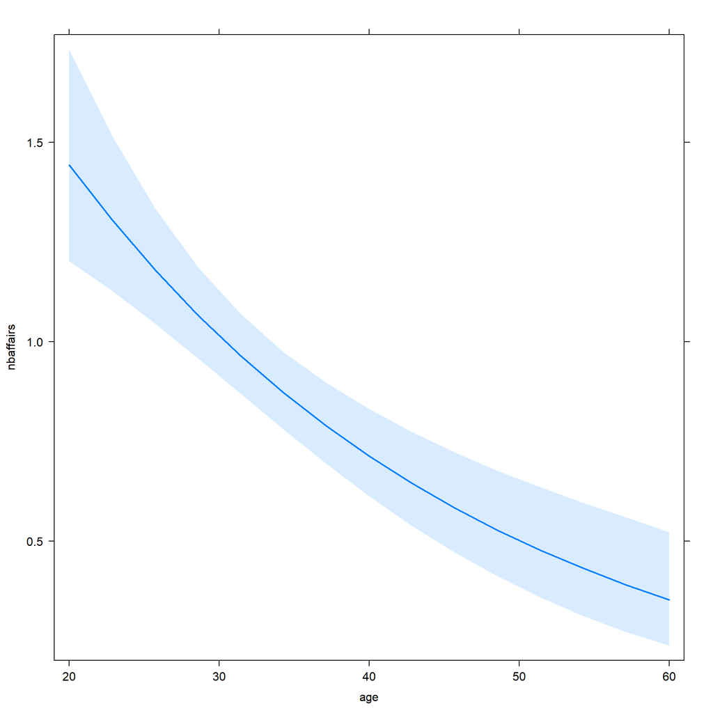

```r
plot(effect("age", fit), ci.style="band", rescale.axis=FALSE, multiline=TRUE, xlab="age", ylab="nbaffairs", rug=FALSE, main="")
```

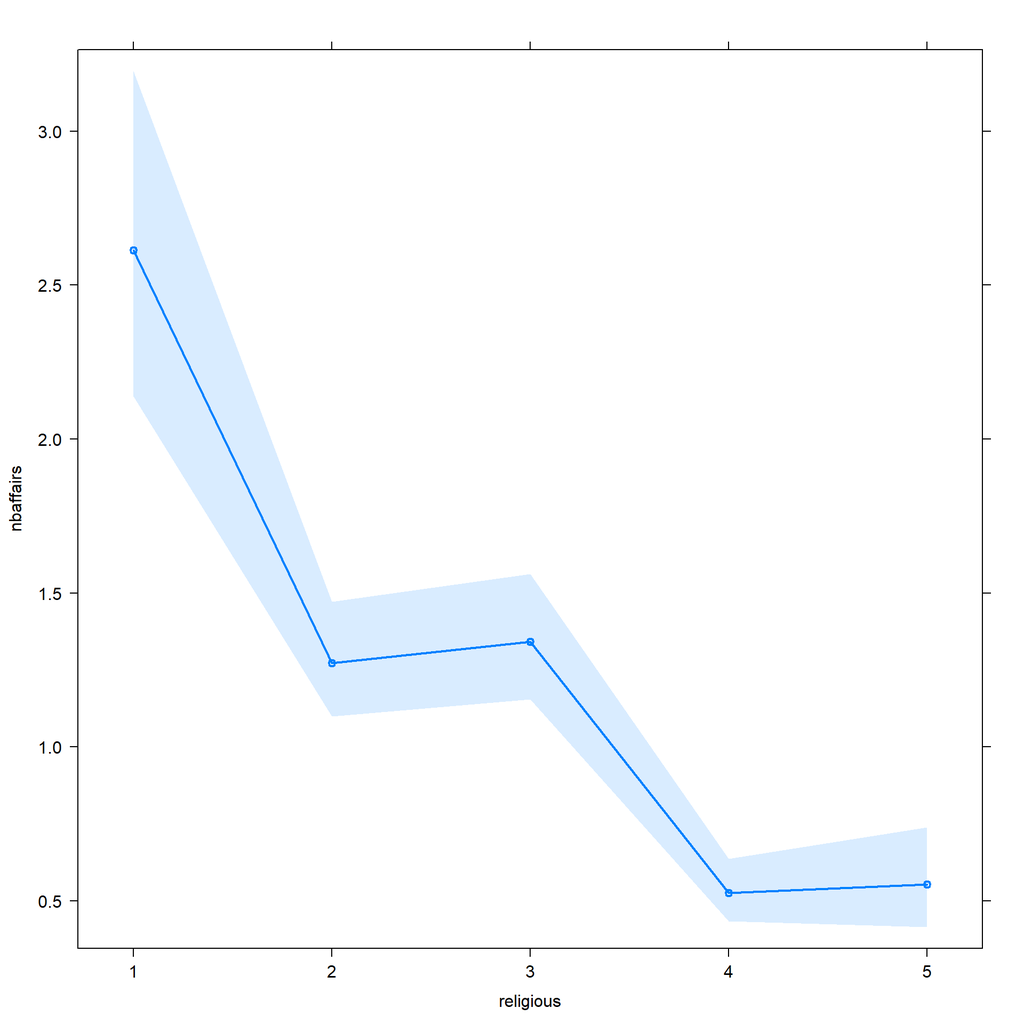

```r
# a very clear relation

plot(effect("religious", fit), ci.style="band", rescale.axis=FALSE, multiline=TRUE, xlab="religious", ylab="nbaffairs", rug=FALSE, main="")
```

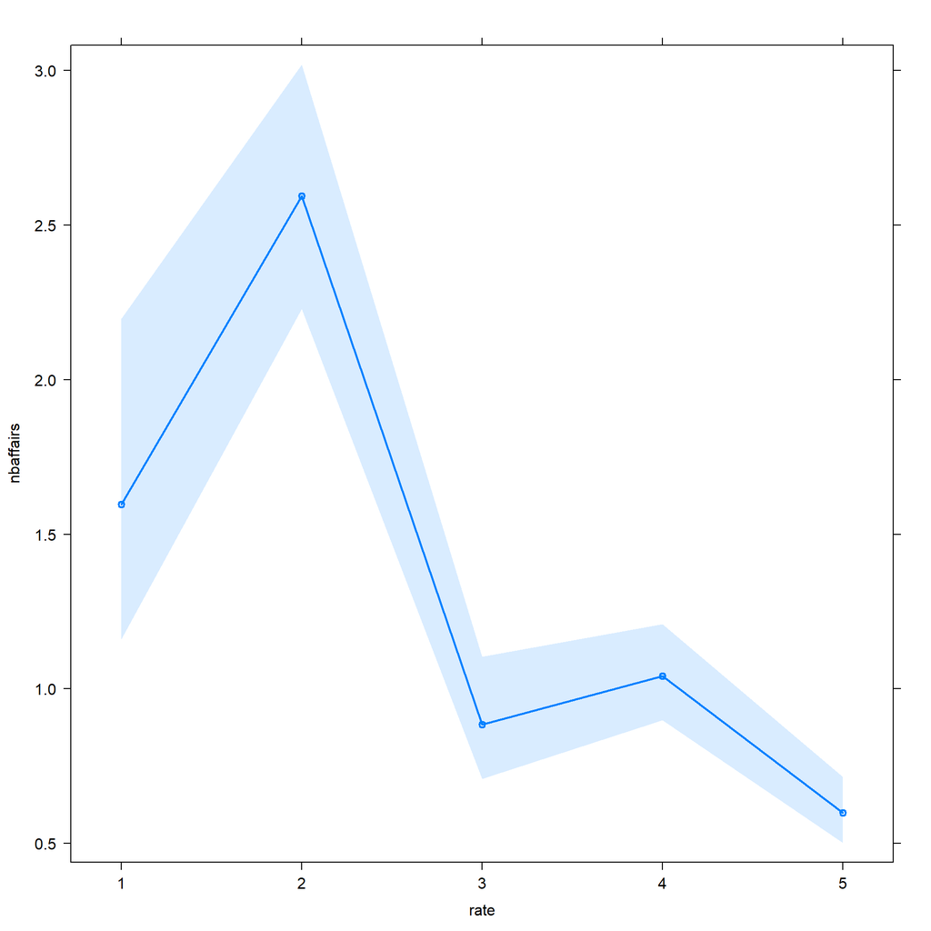

```r
# a very clear (but weaker) relation

plot(effect("rate", fit), ci.style="band", rescale.axis=FALSE, multiline=TRUE, xlab="rate", ylab="nbaffairs", rug=FALSE, main="")
```

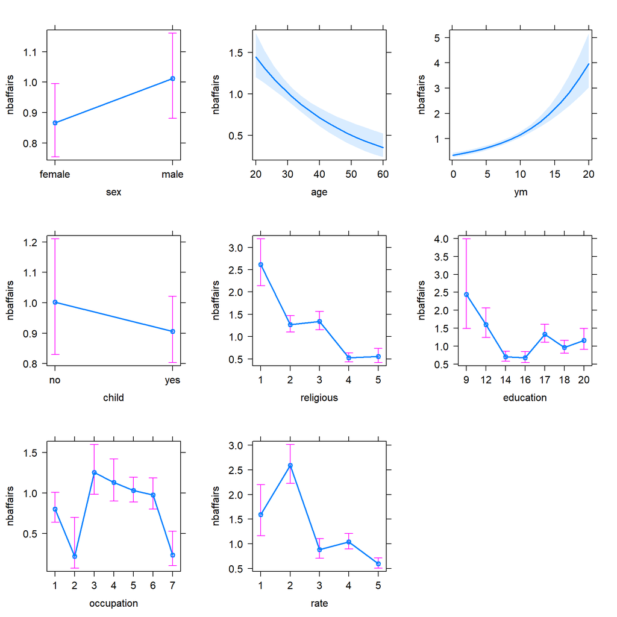

```r
# a very clear relation

# All effects on target:
plot(allEffects(fit), rescale.axis=FALSE, multiline=TRUE, rug=FALSE, main="")
```

Calculamos la media y std de la distribución:

```r
mean(fair$nbaffairs)
```

```
## [1] 1.455907
```

```r
var(fair$nbaffairs)
```

```
## [1] 10.8818
```

Vemos que la varianza es muchísimo mayor a la media en este caso; mientras que en la Poisson: $E(y) = Var(y)$, que es lo mismo que decir $\phi = 1$. Este suceso se llama overdispersion, y una buena forma de atacar un problema de este tipo es mediante el uso de otras distribuciones, como la Quasi-Poisson que utiliza $\phi \neq 1$, o la Negative Binomial.

De todas formas, a partir de este punto los modelos que plantearemos serán zero inflated, ya que vimos que la variable nbaffairs tiene un gran número de valores en 0; de esta forma podemos dejar que el modelo decida primero si es o no cero, y si no es 0 estime el número de infidelidades del último año. Primero volveremos a ajustar una poisson de esta forma.

```r
fit1 <-  zeroinfl(nbaffairs ~ .,
                     dist = "poisson",
                     data = train)

summary(fit1)
```

```
##
## Call:
## zeroinfl(formula = nbaffairs ~ ., data = train, dist = "poisson")
##
## Pearson residuals:
##     Min      1Q  Median      3Q     Max
## -1.3084 -0.5239 -0.3450 -0.2105 18.4922
##
## Count model coefficients (poisson with log link):
##              Estimate Std. Error z value Pr(>|z|)
## (Intercept)  1.572016   0.236874   6.637 3.21e-11 ***
## sexmale     -0.042895   0.104164  -0.412 0.680487
## age         -0.003623   0.007768  -0.466 0.640925
## ym           0.050609   0.013026   3.885 0.000102 ***
## childyes    -0.228146   0.116383  -1.960 0.049959 *
## religious.L -0.395308   0.124382  -3.178 0.001482 **
## religious.Q -0.039103   0.111392  -0.351 0.725561
## religious.C  0.046046   0.099447   0.463 0.643348
## religious^4 -0.036306   0.088628  -0.410 0.682068
## education.L -0.553297   0.212629  -2.602 0.009264 **
## education.Q  0.619038   0.177092   3.496 0.000473 ***
## education.C -0.068260   0.158941  -0.429 0.667583
## education^4 -0.197210   0.124422  -1.585 0.112964
## education^5  0.187961   0.104076   1.806 0.070920 .
## education^6  0.045652   0.112135   0.407 0.683921
## occupation2 -3.048334   0.601852  -5.065 4.09e-07 ***
## occupation3  0.083581   0.173062   0.483 0.629127
## occupation4 -0.086370   0.166583  -0.518 0.604124
## occupation5  0.310048   0.147592   2.101 0.035667 *
## occupation6  0.152395   0.182042   0.837 0.402514
## occupation7 -0.976929   0.522502  -1.870 0.061524 .
## rate.L      -0.156623   0.132255  -1.184 0.236313
## rate.Q      -0.028218   0.129676  -0.218 0.827739
## rate.C       0.161381   0.093338   1.729 0.083809 .
## rate^4      -0.144029   0.105016  -1.371 0.170221
##
## Zero-inflation model coefficients (binomial with logit link):
##               Estimate Std. Error z value Pr(>|z|)
## (Intercept)    0.62728    0.62670   1.001  0.31686
## sexmale       -0.26358    0.28888  -0.912  0.36155
```

[output cut: 13 more lines]

```
## occupation2  -19.10783 3816.78003  -0.005  0.99601
## occupation3   -0.65305    0.48847  -1.337  0.18125
## occupation4   -0.66940    0.46309  -1.445  0.14832
## occupation5    0.01310    0.39114   0.033  0.97328
## occupation6   -0.06971    0.47385  -0.147  0.88304
## occupation7   -0.09462    0.88683  -0.107  0.91504
## rate.L         1.18452    0.42735   2.772  0.00558 **
## rate.Q         0.28701    0.38690   0.742  0.45821
## rate.C        -0.15501    0.29397  -0.527  0.59800
## rate^4         0.57731    0.27494   2.100  0.03575 *
## ---
## Signif. codes:  0 '***' 0.001 '**' 0.01 '*' 0.05 '.' 0.1 ' ' 1
##
## Number of iterations in BFGS optimization: 76
## Log-likelihood: -596.3 on 50 Df
```

```r
AIC(fit1)
```

```
## [1] 1292.554
```

Vemos que con este modelo el AIC baja bastante. Al hacer el modelo zeroinflated, la interpretación de los coeficientes es algo más complicada. Tenemos dos outputs del modelo, uno para la parte de si es 0 o no la variable, que se modeliza como una Bernoulli con logit function como link function, y luego otro modelo de Poisson para los que no son 0.

Vemos que para determinar si son 0 o no las variables importantes son la edad, el número de años casados, el nivel de religiosidad 2, así como el 5; además, el rate de nivel 2 y el rate de nivel 5 también son significativos a la hora de determinar si las infidelidades serán 0 o no.

Por otro lado, para determinar el número de infidelidades una vez se ha determinado por el modelo que éstas no son 0, son importantes el número de años casados que lleva la pareja, el tener hijos, ser religioso nivel 2, la educación en varios niveles, ser del nivel de ocupación 2 o 5, y tener un rate de satisfacción matrimonial de 4.

```
##             Count_model Zero_inflation_model
## (Intercept)  4.81634954         1.872517e+00
## sexmale      0.95801216         7.682972e-01
## age          0.99638347         1.045893e+00
## ym           1.05191183         9.066010e-01
## childyes     0.79600788         7.295353e-01
## religious.L  0.67347244         3.127617e+00
## religious.Q  0.96165211         7.921547e-01
## religious.C  1.04712262         1.120535e+00
## religious^4  0.96434513         4.790724e-01
## education.L  0.57505085         9.751895e-01
## education.Q  1.85714100         8.322091e-01
## education.C  0.93401766         1.530472e+00
## education^4  0.82101785         1.073800e+00
## education^5  1.20678672         7.119469e-01
## education^6  1.04671048         8.544859e-01
## occupation2  0.04743791         5.030055e-09
## occupation3  1.08717364         5.204556e-01
## occupation4  0.91725481         5.120175e-01
## occupation5  1.36349090         1.013187e+00
## occupation6  1.16461979         9.326629e-01
## occupation7  0.37646541         9.097223e-01
## rate.L       0.85502615         3.269113e+00
## rate.Q       0.97217658         1.332432e+00
## rate.C       1.17513298         8.564097e-01
## rate^4       0.86586268         1.781234e+00
```

Aquí podemos ver los coeficientes ya pasados a exponencial (al utilizar como link function el logaritmo, tenemos que utilizar la exponencial para sacar el verdadero valor de las $\beta$).

Ajustamos por tanto un GLM con la Quasi-Poisson:

```r
fit <- glm(nbaffairs ~., family = quasipoisson(link = "log"), data = train)

summary(fit)
```

```
##
## Call:
## glm(formula = nbaffairs ~ ., family = quasipoisson(link = "log"),
##     data = train)
##
## Deviance Residuals:
##     Min       1Q   Median       3Q      Max
## -3.7475  -1.5010  -1.0713  -0.6031   9.1482
##
## Coefficients:
##             Estimate Std. Error t value Pr(>|t|)
## (Intercept)  0.48794    0.55807   0.874 0.382367
## sexmale      0.15530    0.26613   0.584 0.559799
## age         -0.03525    0.01911  -1.845 0.065686 .
## ym           0.12285    0.03415   3.597 0.000355 ***
## childyes    -0.10180    0.31647  -0.322 0.747846
## religious.L -1.26142    0.33192  -3.800 0.000163 ***
## religious.Q  0.14775    0.29136   0.507 0.612295
## religious.C  0.06845    0.25737   0.266 0.790381
## religious^4  0.44809    0.21711   2.064 0.039554 *
## education.L -0.49047    0.54838  -0.894 0.371552
## education.Q  0.76308    0.44937   1.698 0.090128 .
## education.C -0.35713    0.38395  -0.930 0.352767
## education^4 -0.18980    0.32582  -0.583 0.560477
## education^5  0.49071    0.25948   1.891 0.059198 .
## education^6  0.17305    0.28871   0.599 0.549195
## occupation2 -1.30046    1.69391  -0.768 0.443023
## occupation3  0.44780    0.44242   1.012 0.311958
## occupation4  0.34493    0.44385   0.777 0.437461
## occupation5  0.25176    0.38097   0.661 0.509035
## occupation6  0.19598    0.45745   0.428 0.668536
## occupation7 -1.23689    1.23436  -1.002 0.316819
## rate.L      -0.90904    0.33091  -2.747 0.006236 **
## rate.Q      -0.22377    0.32807  -0.682 0.495529
## rate.C       0.26661    0.23628   1.128 0.259729
## rate^4      -0.56872    0.26105  -2.179 0.029841 *
## ---
## Signif. codes:  0 '***' 0.001 '**' 0.01 '*' 0.05 '.' 0.1 ' ' 1
##
## (Dispersion parameter for quasipoisson family taken to be 7.968771)
##
##     Null deviance: 2542.1  on 509  degrees of freedom
## Residual deviance: 1880.0  on 485  degrees of freedom
## AIC: NA
##
## Number of Fisher Scoring iterations: 7
```

No obtenemos ningún AIC para este modelo; si nos fijamos en el Null deviance y el Residual Deviance, son iguales a los del ajuste de Poisson…

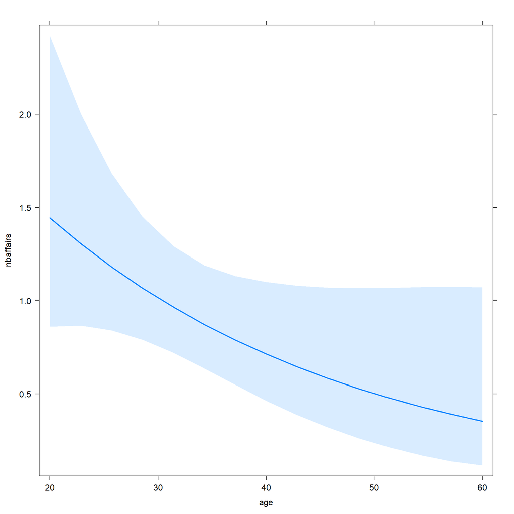

```r
plot(effect("age", fit), ci.style="band", rescale.axis=FALSE, multiline=TRUE, xlab="age", ylab="nbaffairs", rug=FALSE, main="")
```

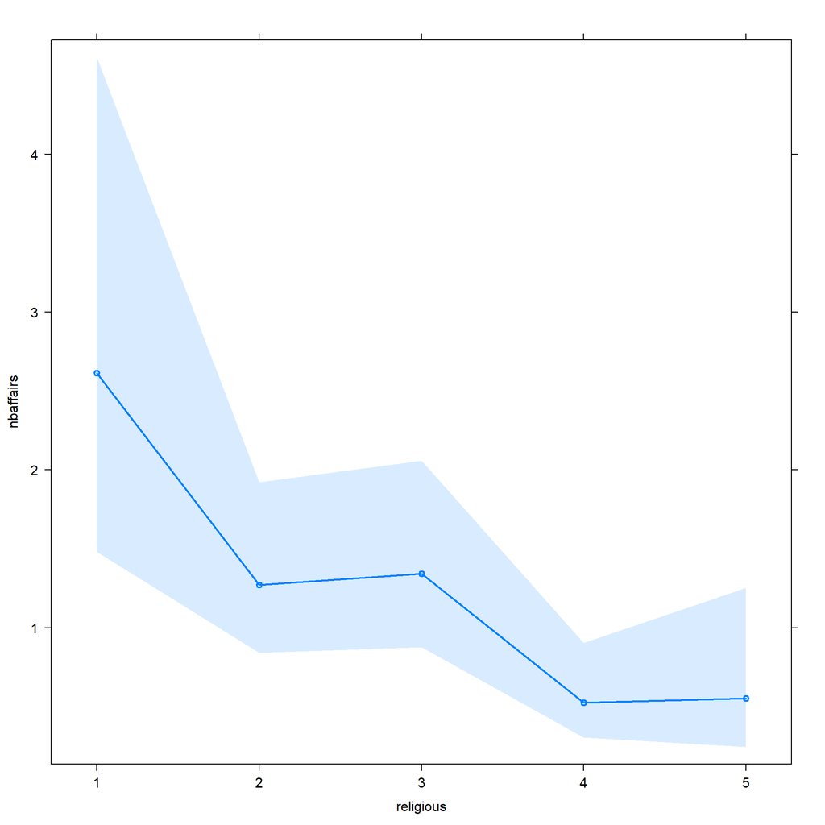

```r
# a very clear relation

plot(effect("religious", fit), ci.style="band", rescale.axis=FALSE, multiline=TRUE, xlab="religious", ylab="nbaffairs", rug=FALSE, main="")
```

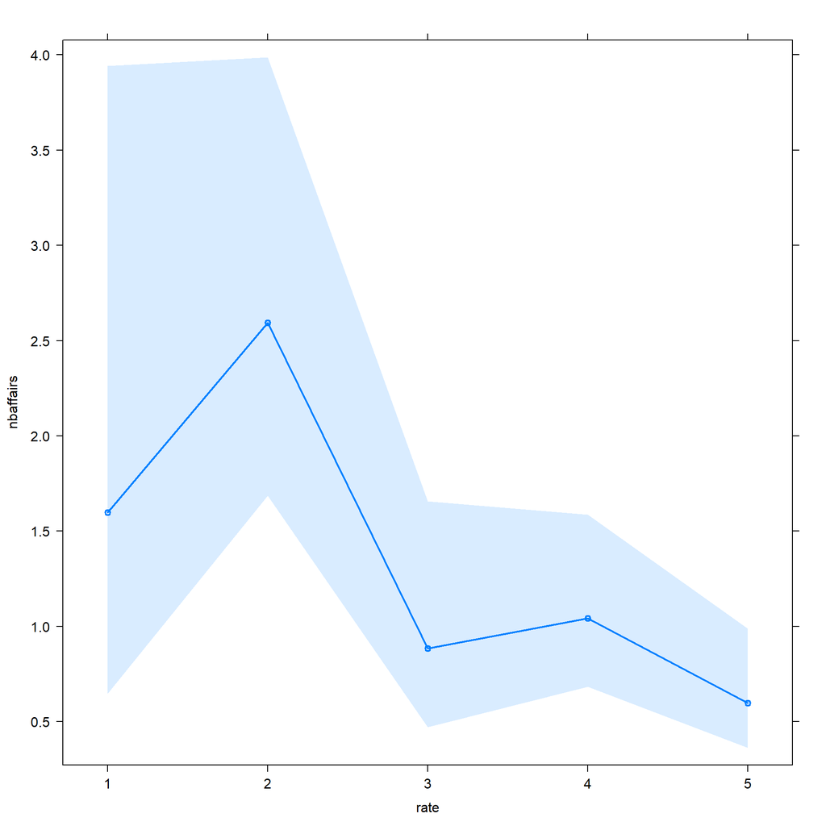

```r
# a very clear (but weaker) relation

plot(effect("rate", fit), ci.style="band", rescale.axis=FALSE, multiline=TRUE, xlab="rate", ylab="nbaffairs", rug=FALSE, main="")
```

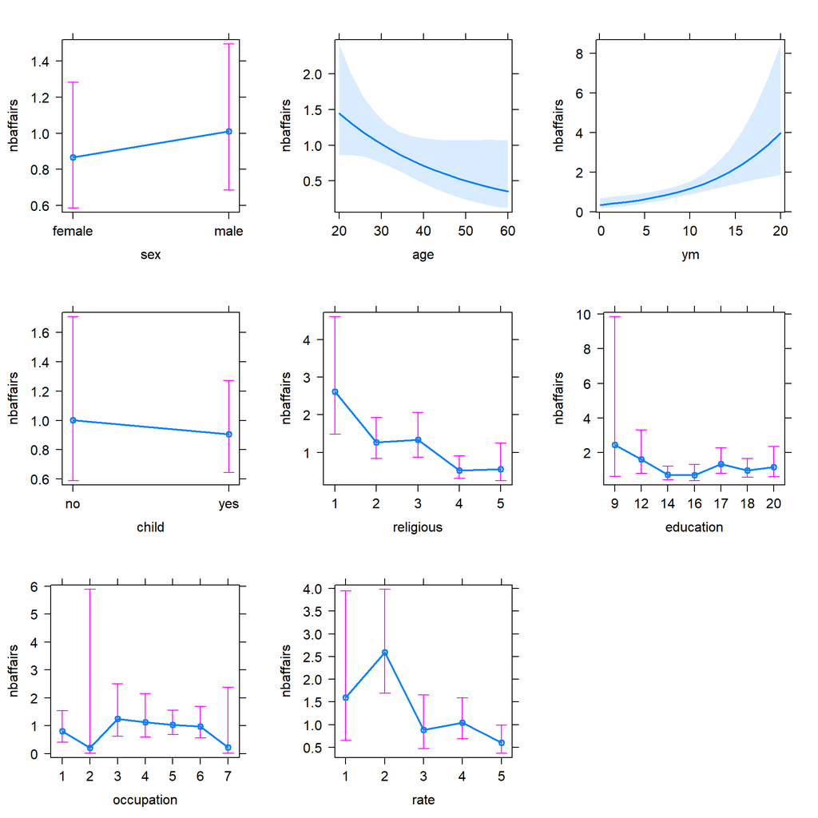

```r
# a very clear relation

# All effects on target:
plot(allEffects(fit), rescale.axis=FALSE, multiline=TRUE, rug=FALSE, main="")
```

Si nos fijamos bien, en el último gráfico se puede apreciar que el efecto estimado de las variables sobre nbaffairs es verdaderamente parecido a cuando usábamos la Poisson sin más. Quizás cambian un poco los intervalos de confianza calculados, debido al nuevo parámetro introducido que precisamente tiene en cuenta la dispersión. De ahí que en algunos casos donde en el anterior gráfico, para el modelo de Poisson, no teníamos apenas sombra (esta representa la incertidumbre de la estimación: la línea marcada), en este caso sí la tenemos.

```r
#exp(cbind(coef(fit), confint(fit)))
```

Ajustaremos ahora una binomial negativa, ya con el zero inflated. No tiene sentido seguir probando modelos que no sean zero inflated, pues la variable nbaffairs tiene claramente muchísimos ceros.

```r
fit.nbin <-  zeroinfl(nbaffairs ~ .,
                     dist = "negbin",
                     data = train)

summary(fit.nbin)
```

```
##
## Call:
## zeroinfl(formula = nbaffairs ~ ., data = train, dist = "negbin")
##
## Pearson residuals:
##     Min      1Q  Median      3Q     Max
## -0.9429 -0.4546 -0.3136 -0.1922 15.0038
##
## Count model coefficients (negbin with log link):
##              Estimate Std. Error z value Pr(>|z|)
## (Intercept)  1.129527   0.520743   2.169  0.03008 *
## sexmale     -0.065781   0.212507  -0.310  0.75691
## age          0.009444   0.015617   0.605  0.54535
## ym           0.049485   0.024859   1.991  0.04652 *
## childyes    -0.258831   0.227190  -1.139  0.25459
## religious.L -0.488360   0.248923  -1.962  0.04978 *
## religious.Q -0.204036   0.240855  -0.847  0.39692
## religious.C  0.024007   0.193612   0.124  0.90132
## religious^4 -0.177340   0.188681  -0.940  0.34727
## education.L -0.729347   0.471885  -1.546  0.12220
## education.Q  0.817720   0.434381   1.882  0.05977 .
## education.C -0.383604   0.399927  -0.959  0.33747
## education^4 -0.248318   0.258919  -0.959  0.33753
## education^5  0.176121   0.212399   0.829  0.40699
## education^6  0.077031   0.214380   0.359  0.71936
## occupation2 -1.836027   1.074898  -1.708  0.08762 .
## occupation3  0.261258   0.367516   0.711  0.47716
## occupation4 -0.273638   0.315293  -0.868  0.38546
## occupation5  0.324235   0.280071   1.158  0.24699
## occupation6  0.077313   0.356180   0.217  0.82816
## occupation7 -1.213005   0.772105  -1.571  0.11617
## rate.L      -0.196801   0.275747  -0.714  0.47541
## rate.Q      -0.230703   0.289998  -0.796  0.42630
## rate.C       0.190461   0.190578   0.999  0.31761
## rate^4      -0.114806   0.203720  -0.564  0.57306
## Log(theta)   0.925644   0.280329   3.302  0.00096 ***
##
## Zero-inflation model coefficients (binomial with logit link):
##              Estimate Std. Error z value Pr(>|z|)
## (Intercept)  0.340386   0.660744   0.515 0.606444
```

[output cut: 15 more lines]

```
## occupation3 -0.554326   0.510276  -1.086 0.277335
## occupation4 -0.773292   0.502979  -1.537 0.124189
## occupation5  0.099153   0.406137   0.244 0.807125
## occupation6  0.002231   0.498228   0.004 0.996427
## occupation7 -0.255580   1.042413  -0.245 0.806316
## rate.L       1.284157   0.448342   2.864 0.004180 **
## rate.Q       0.114799   0.401242   0.286 0.774796
## rate.C      -0.087380   0.306885  -0.285 0.775850
## rate^4       0.594538   0.287980   2.065 0.038969 *
## ---
## Signif. codes:  0 '***' 0.001 '**' 0.01 '*' 0.05 '.' 0.1 ' ' 1
##
## Theta = 2.5235
## Number of iterations in BFGS optimization: 61
## Log-likelihood: -563.5 on 51 Df
```

```r
AIC(fit.nbin)
```

```
## [1] 1229.006
```

El AIC mejora con respecto a la Poisson, con lo cual este modelo es mejor a la hora de explicar la variable nbaffairs.

En teoría explica un poco mejor que el modelo de Poisson o el de QuasiPoisson; además, vemos que en este caso la variable sexmale, que antes había salido más o menos significativa, ahora sale totalmente no significativa… La edad tampoco sale nada significativa, cuando antes sí parecía serlo. Vemos por lo tanto que existen algunas discrepancias entre este modelo y el que estimamos por Poisson o por QuasiPoisson.

## Variable Rate

```r
summary(train$rate)
```

```
##   1   2   3   4   5
##  15  63  75 161 196
```

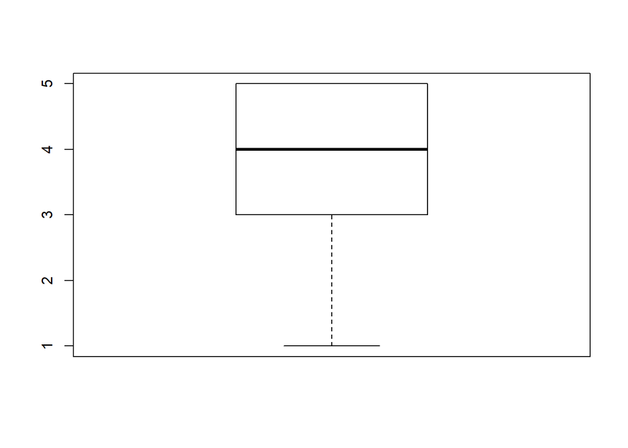

```r
boxplot(train$rate)
```

```r
#hist(train$rate)
```

Es claramente una variable ordinal, ordenada de 1 (más infeliz con la pareja) a 5 (más feliz con la pareja).

Comenzaremos ajustando un modelo de regresión logística con multiclase ordenada, aunque sabemos que la regresión logística donde funciona muy bien es en el binary setting, y es probable que al predecir multiclase ordenada haya otros modelos mejores.

```r
fit.r <- polr(rate ~., data = train)

summary(fit.r)
```

```
##
## Re-fitting to get Hessian
```

```
## Call:
## polr(formula = rate ~ ., data = train)
##
## Coefficients:
##                Value Std. Error  t value
## sexmale     -0.13109    0.21313 -0.61506
## age         -0.02162    0.01581 -1.36711
## ym          -0.02344    0.02829 -0.82835
## childyes    -0.62278    0.24459 -2.54619
## religious.L -0.16993    0.28414 -0.59806
## religious.Q  0.55805    0.24969  2.23498
## religious.C -0.44809    0.19277 -2.32453
## religious^4  0.19221    0.17356  1.10748
## education.L  1.95174    0.56169  3.47477
## education.Q -1.00607    0.49742 -2.02256
## education.C  0.55977    0.39929  1.40190
## education^4  0.22703    0.30538  0.74343
## education^5  0.32055    0.23839  1.34466
## education^6  0.03938    0.20327  0.19371
## occupation2  0.61334    0.58059  1.05640
## occupation3 -0.46458    0.38012 -1.22220
## occupation4  0.08210    0.34057  0.24108
## occupation5  0.01690    0.27362  0.06178
## occupation6 -0.17643    0.34109 -0.51726
## occupation7 -1.33539    0.60100 -2.22196
## nbaffairs   -0.12416    0.02659 -4.66991
##
## Intercepts:
##     Value    Std. Error t value
## 1|2  -5.4127   0.5342   -10.1321
## 2|3  -3.4154   0.4755    -7.1832
## 3|4  -2.4236   0.4641    -5.2223
## 4|5  -0.9019   0.4519    -1.9957
##
## Residual Deviance: 1295.913
## AIC: 1345.913
```

```r
AIC(fit.r)
```

```
## [1] 1345.913
```

Vemos que el AIC para este ajuste es de 1345.913. Podríamos probar, como haremos más adelante, otras link function, por si al tomar otra distribución preliminar de los datos como la distribución teórica, mejorara el ajuste (medido como AIC).

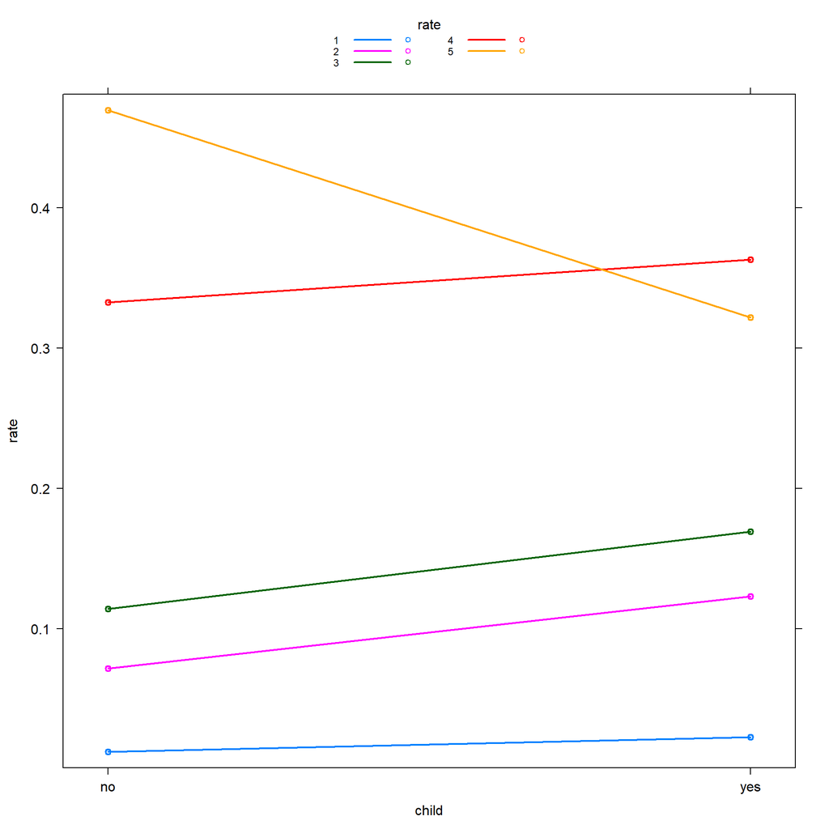